# Task 1

## Web scraping and analysis

We will use a package called `BeautifulSoup` to collect the data from the web. Once we've collected our data and saved it into a local `.csv` file we'll start the analysis.

### Scraping data from Skytrax

If you visit [https://www.airlinequality.com] you can see that there is a lot of data there. For this task, we are only interested in reviews related to British Airways and the Airline itself.

If you navigate to this link: [https://www.airlinequality.com/airline-reviews/british-airways] you will see this data. Now, we can use `Python` and `BeautifulSoup` to collect all the links to the reviews and then to collect the text data on each of the individual review links.

```python
# importing the required libraries

import requests
from bs4 import BeautifulSoup
import pandas as pd
```

```python
# writing the code to scrap the data

base_url = "https://www.airlinequality.com/airline-reviews/british-airways"
pages = 50 # specifying the number of pages
page_size = 100 # specifying the page size

reviews = []

# for i in range(1, pages + 1):
for i in range(1, pages + 1):

    print(f"Scraping page {i}")

    # Create URL to collect links from paginated data
    url = f"{base_url}/page/{i}/?sortby=post_date%3ADesc&pagesize={page_size}"

    # Collect HTML data from this page
    response = requests.get(url)

    # Parse content
    content = response.content
    parsed_content = BeautifulSoup(content, 'html.parser')
    for para in parsed_content.find_all("div", {"class": "text_content"}):
        reviews.append(para.get_text())

    print(f"   ---> {len(reviews)} total reviews")
```

```
Scraping page 1
   ---> 100 total reviews
Scraping page 2
   ---> 200 total reviews
Scraping page 3
   ---> 300 total reviews
Scraping page 4
   ---> 400 total reviews
Scraping page 5
   ---> 500 total reviews
Scraping page 6
   ---> 600 total reviews
Scraping page 7
   ---> 700 total reviews
Scraping page 8
   ---> 800 total reviews
Scraping page 9
   ---> 900 total reviews
Scraping page 10
   ---> 1000 total reviews
Scraping page 11
   ---> 1100 total reviews
Scraping page 12
   ---> 1200 total reviews
Scraping page 13
   ---> 1300 total reviews
Scraping page 14
   ---> 1400 total reviews
Scraping page 15
   ---> 1500 total reviews
Scraping page 16
   ---> 1600 total reviews
Scraping page 17
   ---> 1700 total reviews
Scraping page 18
   ---> 1800 total reviews
Scraping page 19
   ---> 1900 total reviews
Scraping page 20
   ---> 2000 total reviews
```

[output cut: 45 more lines]

```
   ---> 3639 total reviews
Scraping page 44
   ---> 3639 total reviews
Scraping page 45
   ---> 3639 total reviews
Scraping page 46
   ---> 3639 total reviews
Scraping page 47
   ---> 3639 total reviews
Scraping page 48
   ---> 3639 total reviews
Scraping page 49
   ---> 3639 total reviews
Scraping page 50
   ---> 3639 total reviews
```

```python
# putting the data into a data frame

df = pd.DataFrame()
df["reviews"] = reviews
df.head()
```

|  | reviews |
| --- | --- |
| 0 | ✅ Trip Verified \| Flying A380 business class ... |
| 1 | ✅ Trip Verified \| British Airways absolutely ... |
| 2 | ✅ Trip Verified \| My recent experience with B... |
| 3 | ✅ Trip Verified \| This is to express our disp... |
| 4 | ✅ Trip Verified \| I flew London to Malaga on ... |

Saving the data frame in CSV format.

```python
df.to_csv("datareview.csv")
```

The next thing that we will do is clean this data to remove any unnecessary text from each of the rows. For example, "✅ Trip Verified" can be removed from each row if it exists, as it's not relevant to what we want to investigate.

## Data cleaning

```python
# import required libraries

import pandas as pd
import nltk
from nltk.corpus import stopwords
from nltk.stem import WordNetLemmatizer
import string
nltk.download('stopwords')
nltk.download('punkt')
nltk.download('wordnet')
nltk.download('omw-1.4')
```

```
True
```

```python
# Load the data into a pandas DataFrame
data = pd.read_csv("datareview.csv")

# Preprocess the text data

data["clean_text"] = data["reviews"].str.lower()  # Convert text to lowercase

data['clean_text'] = data['clean_text'].str.replace('trip verified', '')

# Remove leading and trailing whitespaces
data['clean_text'] = data['clean_text'].str.strip()

# Remove punctuation and numbers
data["clean_text"] = data["clean_text"].str.replace("[^\w\s]", "")
data["clean_text"] = data["clean_text"].str.replace("\d+", "")

# Remove stopwords
stop_words = set(stopwords.words("english"))
data["clean_text"] = data["clean_text"].apply(
    lambda x: " ".join(word for word in nltk.word_tokenize(x) if word not in stop_words)
)

# Perform lemmatization
lemmatizer = WordNetLemmatizer()
data["clean_text"] = data["clean_text"].apply(
    lambda x: " ".join(lemmatizer.lemmatize(word) for word in nltk.word_tokenize(x))
)

# Remove remaining special characters
data["clean_text"] = data["clean_text"].str.replace("[^\w\s]", "")

# Remove duplicates
data = data.drop_duplicates(subset=["clean_text"])
```

```python
data.head()
```

|  | Unnamed: 0 | reviews | clean_text |
| --- | --- | --- | --- |
| 0 | 0 | ✅ Trip Verified \| Flying A380 business class ... | flying business class pleasure ba made disaste... |
| 1 | 1 | ✅ Trip Verified \| British Airways absolutely ... | british airway absolutely care reserved seat c... |
| 2 | 2 | ✅ Trip Verified \| My recent experience with B... | recent experience british airway horrendous ut... |
| 3 | 3 | ✅ Trip Verified \| This is to express our disp... | express displeasure concern regarding flight i... |
| 4 | 4 | ✅ Trip Verified \| I flew London to Malaga on ... | flew london malaga august club europe stood ar... |

## Exploratory analysis

```python
!pip install wordcloud
```

```python
import matplotlib.pyplot as plt
from nltk.sentiment import SentimentIntensityAnalyzer
from wordcloud import WordCloud
nltk.download('vader_lexicon')
```

```
True
```

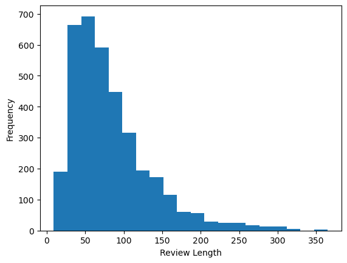

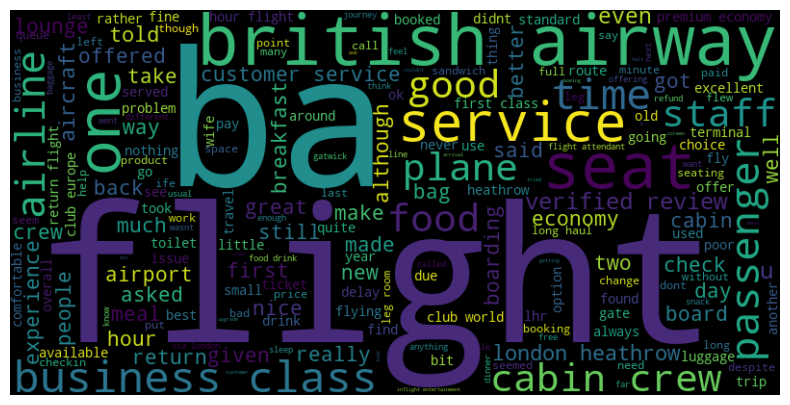

```python
#  carrying out Sentiment Analysis using the SentimentIntensityAnalyzer

sid = SentimentIntensityAnalyzer()
data["sentiment"] = data["clean_text"].apply(lambda x: sid.polarity_scores(x)["compound"])

# Descriptive Analysis
review_lengths = data["clean_text"].apply(lambda x: len(x.split()))
plt.hist(review_lengths, bins=20)
plt.xlabel("Review Length")
plt.ylabel("Frequency")
plt.show()

# Word Cloud
all_reviews = " ".join(data["clean_text"])
wordcloud = WordCloud(width=800, height=400).generate(all_reviews)
plt.figure(figsize=(10, 5))
plt.imshow(wordcloud, interpolation="bilinear")
plt.axis("off")
plt.show()
```

```python
from sklearn.decomposition import LatentDirichletAllocation
from sklearn.feature_extraction.text import CountVectorizer
```

```python
# Topic Modeling using LDA
vectorizer = CountVectorizer(max_features=1000, lowercase=True, stop_words="english")
tf_matrix = vectorizer.fit_transform(data["clean_text"])
lda_model = LatentDirichletAllocation(n_components=20, random_state=42)
lda_model.fit(tf_matrix)

 # Extracting topics
topic_keywords = pd.DataFrame(lda_model.components_, columns=vectorizer.get_feature_names())
top_topics = topic_keywords.idxmax(axis=1)
data["topic"] = top_topics


# Identify common positive and negative words
positive_words = " ".join(data[data["sentiment"] > 0]["clean_text"])
negative_words = " ".join(data[data["sentiment"] < 0]["clean_text"])

# Identify topics and their distribution
topic_distribution = data["topic"].value_counts()

# Provide recommendations based on analysis
```

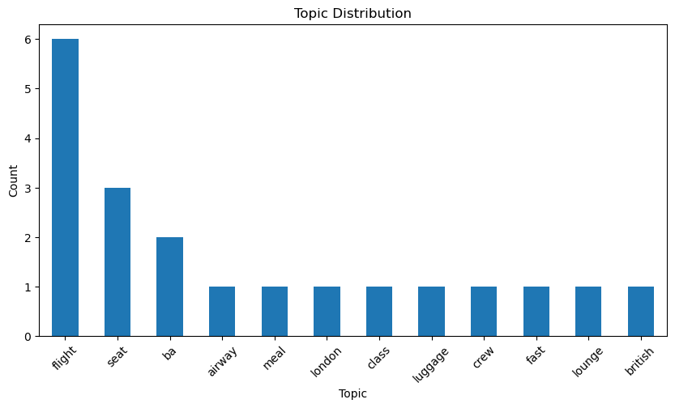

```python
topic_counts = data["topic"].value_counts()

# Plot the topic distribution
plt.figure(figsize=(10, 5))
topic_counts.plot(kind="bar")
plt.xlabel("Topic")
plt.ylabel("Count")
plt.title("Topic Distribution")
plt.xticks(rotation=45)
plt.show()
```

## Top positive words

```python
# Import libraries
import pandas as pd

# Create a DataFrame for positive and negative words
positive_words_df = pd.DataFrame({"word": positive_words.split()})
negative_words_df = pd.DataFrame({"word": negative_words.split()})

# Count the occurrences of positive and negative words
positive_word_counts = positive_words_df["word"].value_counts()
negative_word_counts = negative_words_df["word"].value_counts()

# Print the most common positive and negative words
print("Most Common Positive Words:")
print(positive_word_counts.head(10))
print("\nMost Common Negative Words:")
print(negative_word_counts.head(10))

# Analyze common themes and sentiments
positive_themes = positive_word_counts.index.tolist()
negative_themes = negative_word_counts.index.tolist()
```

```
Most Common Positive Words:
flight     4957
ba         3106
seat       3041
service    1952
good       1831
crew       1696
food       1682
time       1676
cabin      1478
london     1371
Name: word, dtype: int64

Most Common Negative Words:
flight     2632
ba         1737
seat       1357
service     936
hour        813
british     805
airway      799
london      771
airline     745
time        668
Name: word, dtype: int64
```

### common positive and negative words

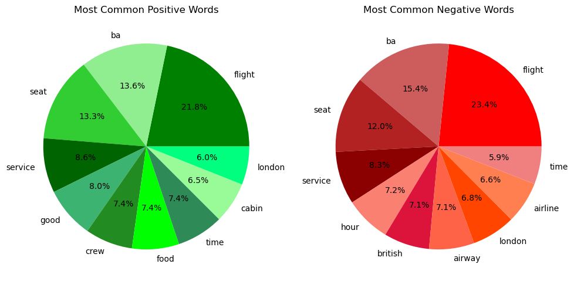

```python
# import matplotlib.pyplot as plt

# Set up the figure and axes
fig, axes = plt.subplots(1, 2, figsize=(10, 5))

# Define colors for the pie charts
colors_positive = ['green', 'lightgreen', 'limegreen', 'darkgreen', 'mediumseagreen',
                   'forestgreen', 'lime', 'seagreen', 'palegreen', 'springgreen']
colors_negative = ['red', 'indianred', 'firebrick', 'darkred', 'salmon',
                   'crimson', 'tomato', 'orangered', 'coral', 'lightcoral']

# Plot the pie chart for most common positive words
axes[0].pie(positive_word_counts.head(10), labels=positive_word_counts.head(10).index,
            autopct='%1.1f%%', colors=colors_positive)
axes[0].set_title('Most Common Positive Words')

# Plot the pie chart for most common negative words
axes[1].pie(negative_word_counts.head(10), labels=negative_word_counts.head(10).index,
            autopct='%1.1f%%', colors=colors_negative)
axes[1].set_title('Most Common Negative Words')

# Adjust the layout
plt.tight_layout()

# Show the plot
plt.show()
```

### positive words and negative words percentages

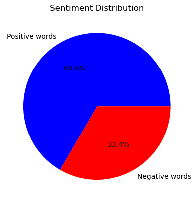

```python
# Prepare data for the pie chart

positive_words_percentage = sum(positive_word_counts)/len(data)*100
negative_words_percentage = sum(negative_word_counts)/len(data)*100

sentiment_labels = ["Positive words", "Negative words"]
sentiment_percentages = [positive_words_percentage, negative_words_percentage]
colors = ["blue", "red"]

# Create the pie chart
plt.pie(sentiment_percentages, labels=sentiment_labels, colors=colors, autopct="%1.1f%%")

# Add a title
plt.title("Sentiment Distribution")

# Display the chart
plt.show()
```